# Risk Factor Analysis

## Outcome Variable

**Outcome Variable:** haz

## Predictor Variables

**Intervention Variable:** enwast

**Adjustment Set:**

- arm
- sex
- W_mage
- meducyrs
- feducyrs
- vagbrth
- single
- brthmon
- W_parity
- delta_W_mage
- delta_meducyrs
- delta_feducyrs
- delta_vagbrth
- delta_single
- delta_brthmon
- delta_W_parity

## Stratifying Variables

The analysis was stratified on these variable(s):

- agecat
- studyid
- country

## Data Summary

| agecat | studyid | country | enwast | n_cell | n |
| --- | --- | --- | --- | --- | --- |
| Birth | ki0047075b-MAL-ED | BANGLADESH | 0 | 179 | 215 |
| Birth | ki0047075b-MAL-ED | BANGLADESH | 1 | 36 | 215 |
| Birth | ki0047075b-MAL-ED | BRAZIL | 0 | 60 | 62 |
| Birth | ki0047075b-MAL-ED | BRAZIL | 1 | 2 | 62 |
| Birth | ki0047075b-MAL-ED | INDIA | 0 | 40 | 45 |
| Birth | ki0047075b-MAL-ED | INDIA | 1 | 5 | 45 |
| Birth | ki0047075b-MAL-ED | NEPAL | 0 | 24 | 26 |
| Birth | ki0047075b-MAL-ED | NEPAL | 1 | 2 | 26 |
| Birth | ki0047075b-MAL-ED | PERU | 0 | 223 | 228 |
| Birth | ki0047075b-MAL-ED | PERU | 1 | 5 | 228 |
| Birth | ki0047075b-MAL-ED | SOUTH AFRICA | 0 | 108 | 121 |
| Birth | ki0047075b-MAL-ED | SOUTH AFRICA | 1 | 13 | 121 |
| Birth | ki0047075b-MAL-ED | TANZANIA, UNITED REPUBLIC OF | 0 | 114 | 115 |
| Birth | ki0047075b-MAL-ED | TANZANIA, UNITED REPUBLIC OF | 1 | 1 | 115 |
| Birth | ki1000108-CMC-V-BCS-2002 | INDIA | 0 | 75 | 87 |
| Birth | ki1000108-CMC-V-BCS-2002 | INDIA | 1 | 12 | 87 |
| Birth | ki1000108-IRC | INDIA | 0 | 251 | 364 |
| Birth | ki1000108-IRC | INDIA | 1 | 113 | 364 |
| Birth | ki1000109-EE | PAKISTAN | 0 | 155 | 180 |
| Birth | ki1000109-EE | PAKISTAN | 1 | 25 | 180 |
| Birth | ki1000109-ResPak | PAKISTAN | 0 | 34 | 38 |
| Birth | ki1000109-ResPak | PAKISTAN | 1 | 4 | 38 |
| Birth | ki1000304b-SAS-CompFeed | INDIA | 0 | 985 | 1105 |
| Birth | ki1000304b-SAS-CompFeed | INDIA | 1 | 120 | 1105 |
| Birth | ki1017093-NIH-Birth | BANGLADESH | 0 | 407 | 580 |
| Birth | ki1017093-NIH-Birth | BANGLADESH | 1 | 173 | 580 |
| Birth | ki1017093b-PROVIDE | BANGLADESH | 0 | 415 | 532 |
| Birth | ki1017093b-PROVIDE | BANGLADESH | 1 | 117 | 532 |
| Birth | ki1017093c-NIH-Crypto | BANGLADESH | 0 | 535 | 713 |
| Birth | ki1017093c-NIH-Crypto | BANGLADESH | 1 | 178 | 713 |

[output cut: 134 more lines]

The following strata were considered:

- agecat: 24 months, studyid: ki0047075b-MAL-ED, country: BANGLADESH
- agecat: 24 months, studyid: ki0047075b-MAL-ED, country: BRAZIL
- agecat: 24 months, studyid: ki0047075b-MAL-ED, country: INDIA
- agecat: 24 months, studyid: ki0047075b-MAL-ED, country: NEPAL
- agecat: 24 months, studyid: ki0047075b-MAL-ED, country: PERU
- agecat: 24 months, studyid: ki0047075b-MAL-ED, country: SOUTH AFRICA
- agecat: 24 months, studyid: ki0047075b-MAL-ED, country: TANZANIA, UNITED REPUBLIC OF
- agecat: 24 months, studyid: ki1000108-CMC-V-BCS-2002, country: INDIA
- agecat: 24 months, studyid: ki1000108-IRC, country: INDIA
- agecat: 24 months, studyid: ki1000109-EE, country: PAKISTAN
- agecat: 24 months, studyid: ki1017093-NIH-Birth, country: BANGLADESH
- agecat: 24 months, studyid: ki1017093b-PROVIDE, country: BANGLADESH
- agecat: 24 months, studyid: ki1017093c-NIH-Crypto, country: BANGLADESH
- agecat: 24 months, studyid: ki1066203-TanzaniaChild2, country: TANZANIA, UNITED REPUBLIC OF
- agecat: 24 months, studyid: ki1101329-Keneba, country: GAMBIA
- agecat: 24 months, studyid: ki1113344-GMS-Nepal, country: NEPAL
- agecat: 24 months, studyid: ki1114097-CMIN, country: BANGLADESH
- agecat: 24 months, studyid: ki1114097-CONTENT, country: PERU
- agecat: 24 months, studyid: ki1119695-PROBIT, country: BELARUS
- agecat: 24 months, studyid: ki1126311-ZVITAMBO, country: ZIMBABWE
- agecat: 24 months, studyid: ki1135781-COHORTS, country: GUATEMALA
- agecat: 24 months, studyid: ki1135781-COHORTS, country: INDIA
- agecat: 24 months, studyid: ki1135781-COHORTS, country: PHILIPPINES
- agecat: 24 months, studyid: ki1148112-LCNI-5, country: MALAWI
- agecat: 24 months, studyid: kiGH5241-JiVitA-3, country: BANGLADESH
- agecat: 24 months, studyid: kiGH5241-JiVitA-4, country: BANGLADESH
- agecat: 6 months, studyid: ki0047075b-MAL-ED, country: BANGLADESH
- agecat: 6 months, studyid: ki0047075b-MAL-ED, country: BRAZIL
- agecat: 6 months, studyid: ki0047075b-MAL-ED, country: INDIA
- agecat: 6 months, studyid: ki0047075b-MAL-ED, country: NEPAL
- agecat: 6 months, studyid: ki0047075b-MAL-ED, country: PERU
- agecat: 6 months, studyid: ki0047075b-MAL-ED, country: SOUTH AFRICA
- agecat: 6 months, studyid: ki0047075b-MAL-ED, country: TANZANIA, UNITED REPUBLIC OF
- agecat: 6 months, studyid: ki1000108-CMC-V-BCS-2002, country: INDIA
- agecat: 6 months, studyid: ki1000108-IRC, country: INDIA
- agecat: 6 months, studyid: ki1000109-EE, country: PAKISTAN
- agecat: 6 months, studyid: ki1000109-ResPak, country: PAKISTAN
- agecat: 6 months, studyid: ki1000304b-SAS-CompFeed, country: INDIA
- agecat: 6 months, studyid: ki1000304b-SAS-FoodSuppl, country: INDIA
- agecat: 6 months, studyid: ki1017093-NIH-Birth, country: BANGLADESH
- agecat: 6 months, studyid: ki1017093b-PROVIDE, country: BANGLADESH
- agecat: 6 months, studyid: ki1017093c-NIH-Crypto, country: BANGLADESH
- agecat: 6 months, studyid: ki1066203-TanzaniaChild2, country: TANZANIA, UNITED REPUBLIC OF
- agecat: 6 months, studyid: ki1101329-Keneba, country: GAMBIA
- agecat: 6 months, studyid: ki1112895-Guatemala BSC, country: GUATEMALA
- agecat: 6 months, studyid: ki1113344-GMS-Nepal, country: NEPAL
- agecat: 6 months, studyid: ki1114097-CMIN, country: BANGLADESH
- agecat: 6 months, studyid: ki1114097-CONTENT, country: PERU
- agecat: 6 months, studyid: ki1119695-PROBIT, country: BELARUS
- agecat: 6 months, studyid: ki1126311-ZVITAMBO, country: ZIMBABWE
- agecat: 6 months, studyid: ki1135781-COHORTS, country: GUATEMALA
- agecat: 6 months, studyid: ki1135781-COHORTS, country: INDIA
- agecat: 6 months, studyid: ki1135781-COHORTS, country: PHILIPPINES
- agecat: 6 months, studyid: ki1148112-LCNI-5, country: MALAWI
- agecat: 6 months, studyid: kiGH5241-JiVitA-3, country: BANGLADESH
- agecat: 6 months, studyid: kiGH5241-JiVitA-4, country: BANGLADESH
- agecat: Birth, studyid: ki0047075b-MAL-ED, country: BANGLADESH
- agecat: Birth, studyid: ki0047075b-MAL-ED, country: BRAZIL
- agecat: Birth, studyid: ki0047075b-MAL-ED, country: INDIA
- agecat: Birth, studyid: ki0047075b-MAL-ED, country: NEPAL
- agecat: Birth, studyid: ki0047075b-MAL-ED, country: PERU
- agecat: Birth, studyid: ki0047075b-MAL-ED, country: SOUTH AFRICA
- agecat: Birth, studyid: ki0047075b-MAL-ED, country: TANZANIA, UNITED REPUBLIC OF
- agecat: Birth, studyid: ki1000108-CMC-V-BCS-2002, country: INDIA
- agecat: Birth, studyid: ki1000108-IRC, country: INDIA
- agecat: Birth, studyid: ki1000109-EE, country: PAKISTAN
- agecat: Birth, studyid: ki1000109-ResPak, country: PAKISTAN
- agecat: Birth, studyid: ki1000304b-SAS-CompFeed, country: INDIA
- agecat: Birth, studyid: ki1017093-NIH-Birth, country: BANGLADESH
- agecat: Birth, studyid: ki1017093b-PROVIDE, country: BANGLADESH
- agecat: Birth, studyid: ki1017093c-NIH-Crypto, country: BANGLADESH
- agecat: Birth, studyid: ki1101329-Keneba, country: GAMBIA
- agecat: Birth, studyid: ki1113344-GMS-Nepal, country: NEPAL
- agecat: Birth, studyid: ki1114097-CMIN, country: BANGLADESH
- agecat: Birth, studyid: ki1114097-CONTENT, country: PERU
- agecat: Birth, studyid: ki1119695-PROBIT, country: BELARUS
- agecat: Birth, studyid: ki1126311-ZVITAMBO, country: ZIMBABWE
- agecat: Birth, studyid: ki1135781-COHORTS, country: GUATEMALA
- agecat: Birth, studyid: ki1135781-COHORTS, country: INDIA
- agecat: Birth, studyid: ki1135781-COHORTS, country: PHILIPPINES
- agecat: Birth, studyid: kiGH5241-JiVitA-3, country: BANGLADESH
- agecat: Birth, studyid: kiGH5241-JiVitA-4, country: BANGLADESH

### Dropped Strata

Some strata were dropped due to rare outcomes:

- agecat: Birth, studyid: ki0047075b-MAL-ED, country: BRAZIL
- agecat: Birth, studyid: ki0047075b-MAL-ED, country: NEPAL
- agecat: Birth, studyid: ki0047075b-MAL-ED, country: TANZANIA, UNITED REPUBLIC OF
- agecat: Birth, studyid: ki1000109-ResPak, country: PAKISTAN
- agecat: Birth, studyid: ki1101329-Keneba, country: GAMBIA
- agecat: Birth, studyid: ki1114097-CMIN, country: BANGLADESH
- agecat: Birth, studyid: ki1114097-CONTENT, country: PERU
- agecat: 6 months, studyid: ki0047075b-MAL-ED, country: TANZANIA, UNITED REPUBLIC OF
- agecat: 6 months, studyid: ki1114097-CONTENT, country: PERU
- agecat: 24 months, studyid: ki0047075b-MAL-ED, country: PERU
- agecat: 24 months, studyid: ki0047075b-MAL-ED, country: TANZANIA, UNITED REPUBLIC OF
- agecat: 24 months, studyid: ki1066203-TanzaniaChild2, country: TANZANIA, UNITED REPUBLIC OF
- agecat: 24 months, studyid: ki1114097-CONTENT, country: PERU

## Methods Detail

We’re interested in the causal parameters $E[Y_a]$ for all values of $a \in \mathcal{A}$. These parameters represent the mean outcome if, possibly contrary to fact, we intervened to set all units to have $A=a$. Under the randomization and positivity assumptions, these are identified by the statistical parameters $\psi_a=E_W[E_{Y|A,W}(Y|A=a,W)]$. In addition, we’re interested in the mean of $Y$, $E[Y]$ under no intervention (the observed mean). We will estimate these parameters by using SuperLearner to fit the relevant likelihood factors – $E_{Y|A,W}(Y|A=a,W)$ and $p(A=a|W)$, and then updating our likelihood fit using a joint TMLE.

For unadjusted analyses ($W=\{\}$), initial likelihoods were estimated using Lrnr_glm to estimate the simple $E(Y|A)$ and Lrnr_mean to estimate $p(A)$. For adjusted analyses, a small library containing Lrnr_glmnet, Lrnr_xgboost, and Lrnr_mean was used.

Having estimated these parameters, we will then use the delta method to estimate relative risks and attributable risks relative to a prespecified baseline level of $A$.

# Results Detail

## Results Plots

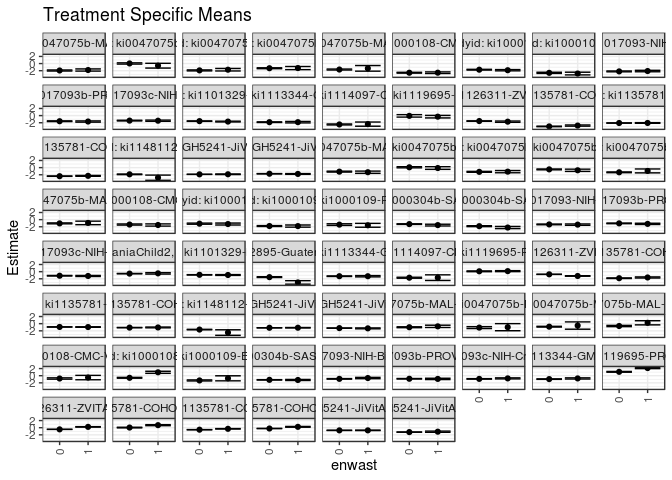

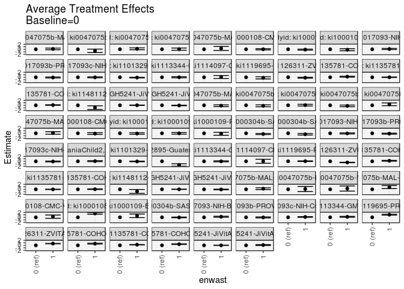

[figure not shown]

## Results Table

### Parameter: TSM

| agecat | studyid | country | intervention_level | baseline_level | estimate | ci_lower | ci_upper |
| --- | --- | --- | --- | --- | --- | --- | --- |
| Birth | ki0047075b-MAL-ED | BANGLADESH | 0 | NA | -0.9942392 | -1.1231549 | -0.8653236 |
| Birth | ki0047075b-MAL-ED | BANGLADESH | 1 | NA | -0.7500185 | -1.0729251 | -0.4271119 |
| Birth | ki0047075b-MAL-ED | INDIA | 0 | NA | -1.0995000 | -1.3601155 | -0.8388845 |
| Birth | ki0047075b-MAL-ED | INDIA | 1 | NA | -0.9800000 | -1.9772048 | 0.0172048 |
| Birth | ki0047075b-MAL-ED | PERU | 0 | NA | -0.8421525 | -0.9539315 | -0.7303735 |
| Birth | ki0047075b-MAL-ED | PERU | 1 | NA | -0.5260000 | -1.5481689 | 0.4961689 |
| Birth | ki0047075b-MAL-ED | SOUTH AFRICA | 0 | NA | -0.6522098 | -0.8189903 | -0.4854292 |
| Birth | ki0047075b-MAL-ED | SOUTH AFRICA | 1 | NA | 0.2440213 | -0.3356804 | 0.8237231 |
| Birth | ki1000108-CMC-V-BCS-2002 | INDIA | 0 | NA | -0.7891409 | -0.9759696 | -0.6023122 |
| Birth | ki1000108-CMC-V-BCS-2002 | INDIA | 1 | NA | -0.5238176 | -1.1456507 | 0.0980154 |
| Birth | ki1000108-IRC | INDIA | 0 | NA | -0.5956046 | -0.7160470 | -0.4751622 |
| Birth | ki1000108-IRC | INDIA | 1 | NA | 0.9508927 | 0.6586914 | 1.2430940 |
| Birth | ki1000109-EE | PAKISTAN | 0 | NA | -1.3293665 | -1.4698348 | -1.1888982 |
| Birth | ki1000109-EE | PAKISTAN | 1 | NA | -0.7300738 | -1.4344906 | -0.0256570 |
| Birth | ki1000304b-SAS-CompFeed | INDIA | 0 | NA | -1.1592754 | -1.2085888 | -1.1099620 |
| Birth | ki1000304b-SAS-CompFeed | INDIA | 1 | NA | -1.2023935 | -1.3506267 | -1.0541603 |
| Birth | ki1017093-NIH-Birth | BANGLADESH | 0 | NA | -0.8857324 | -0.9715509 | -0.7999140 |
| Birth | ki1017093-NIH-Birth | BANGLADESH | 1 | NA | -0.6582894 | -0.8421088 | -0.4744699 |
| Birth | ki1017093b-PROVIDE | BANGLADESH | 0 | NA | -0.8603779 | -0.9406223 | -0.7801335 |
| Birth | ki1017093b-PROVIDE | BANGLADESH | 1 | NA | -0.9009753 | -1.0836631 | -0.7182875 |
| Birth | ki1017093c-NIH-Crypto | BANGLADESH | 0 | NA | -0.8943793 | -0.9696212 | -0.8191374 |
| Birth | ki1017093c-NIH-Crypto | BANGLADESH | 1 | NA | -0.7544785 | -0.9007130 | -0.6082439 |
| Birth | ki1113344-GMS-Nepal | NEPAL | 0 | NA | -0.9532626 | -1.0296461 | -0.8768791 |
| Birth | ki1113344-GMS-Nepal | NEPAL | 1 | NA | -0.7653642 | -0.9315858 | -0.5991425 |
| Birth | ki1119695-PROBIT | BELARUS | 0 | NA | 1.0833471 | 0.9767567 | 1.1899376 |
| Birth | ki1119695-PROBIT | BELARUS | 1 | NA | 2.1393460 | 1.9737403 | 2.3049518 |
| Birth | ki1126311-ZVITAMBO | ZIMBABWE | 0 | NA | -0.4605297 | -0.4781366 | -0.4429229 |
| Birth | ki1126311-ZVITAMBO | ZIMBABWE | 1 | NA | 0.2363067 | 0.1798697 | 0.2927437 |
| Birth | ki1135781-COHORTS | GUATEMALA | 0 | NA | 0.0455076 | -0.0437674 | 0.1347825 |
| Birth | ki1135781-COHORTS | GUATEMALA | 1 | NA | 0.7172515 | 0.5728765 | 0.8616266 |

[output cut: 108 more lines]

### Parameter: E(Y)

| agecat | studyid | country | intervention_level | baseline_level | estimate | ci_lower | ci_upper |
| --- | --- | --- | --- | --- | --- | --- | --- |
| Birth | ki0047075b-MAL-ED | BANGLADESH | NA | NA | -0.9625581 | -1.0817638 | -0.8433525 |
| Birth | ki0047075b-MAL-ED | INDIA | NA | NA | -1.0862222 | -1.3432542 | -0.8291902 |
| Birth | ki0047075b-MAL-ED | PERU | NA | NA | -0.8352193 | -0.9473216 | -0.7231170 |
| Birth | ki0047075b-MAL-ED | SOUTH AFRICA | NA | NA | -0.5594215 | -0.7261377 | -0.3927053 |
| Birth | ki1000108-CMC-V-BCS-2002 | INDIA | NA | NA | -0.8194253 | -1.0062738 | -0.6325768 |
| Birth | ki1000108-IRC | INDIA | NA | NA | -0.1131044 | -0.2551572 | 0.0289484 |
| Birth | ki1000109-EE | PAKISTAN | NA | NA | -1.2383333 | -1.3946042 | -1.0820625 |
| Birth | ki1000304b-SAS-CompFeed | INDIA | NA | NA | -1.1641176 | -1.2153187 | -1.1129166 |
| Birth | ki1017093-NIH-Birth | BANGLADESH | NA | NA | -0.8156034 | -0.8972149 | -0.7339920 |
| Birth | ki1017093b-PROVIDE | BANGLADESH | NA | NA | -0.8579887 | -0.9311892 | -0.7847883 |
| Birth | ki1017093c-NIH-Crypto | BANGLADESH | NA | NA | -0.8487377 | -0.9161997 | -0.7812758 |
| Birth | ki1113344-GMS-Nepal | NEPAL | NA | NA | -0.9117209 | -0.9811840 | -0.8422578 |
| Birth | ki1119695-PROBIT | BELARUS | NA | NA | 1.3292725 | 1.1705582 | 1.4879867 |
| Birth | ki1126311-ZVITAMBO | ZIMBABWE | NA | NA | -0.3412145 | -0.3591726 | -0.3232564 |
| Birth | ki1135781-COHORTS | GUATEMALA | NA | NA | 0.2220341 | 0.1435838 | 0.3004845 |
| Birth | ki1135781-COHORTS | INDIA | NA | NA | -0.5071369 | -0.5319444 | -0.4823294 |
| Birth | ki1135781-COHORTS | PHILIPPINES | NA | NA | -0.1490962 | -0.1843045 | -0.1138879 |
| Birth | kiGH5241-JiVitA-3 | BANGLADESH | NA | NA | -0.7423283 | -0.7679323 | -0.7167243 |
| Birth | kiGH5241-JiVitA-4 | BANGLADESH | NA | NA | -1.2196123 | -1.2608853 | -1.1783394 |
| 6 months | ki0047075b-MAL-ED | BANGLADESH | NA | NA | -1.1551820 | -1.2728984 | -1.0374655 |
| 6 months | ki0047075b-MAL-ED | BRAZIL | NA | NA | 0.0859715 | -0.0613794 | 0.2333224 |
| 6 months | ki0047075b-MAL-ED | INDIA | NA | NA | -1.1905891 | -1.3084276 | -1.0727506 |
| 6 months | ki0047075b-MAL-ED | NEPAL | NA | NA | -0.5342241 | -0.6451165 | -0.4233318 |
| 6 months | ki0047075b-MAL-ED | PERU | NA | NA | -1.3046429 | -1.4135547 | -1.1957310 |
| 6 months | ki0047075b-MAL-ED | SOUTH AFRICA | NA | NA | -1.0498419 | -1.1750104 | -0.9246734 |
| 6 months | ki1000108-CMC-V-BCS-2002 | INDIA | NA | NA | -1.4223508 | -1.5654032 | -1.2792984 |
| 6 months | ki1000108-IRC | INDIA | NA | NA | -1.1707373 | -1.3023712 | -1.0391035 |
| 6 months | ki1000109-EE | PAKISTAN | NA | NA | -1.7873630 | -1.9021295 | -1.6725965 |
| 6 months | ki1000109-ResPak | PAKISTAN | NA | NA | -1.4274196 | -1.6382670 | -1.2165722 |
| 6 months | ki1000304b-SAS-CompFeed | INDIA | NA | NA | -1.2781121 | -1.3694457 | -1.1867786 |
| 6 months | ki1000304b-SAS-FoodSuppl | INDIA | NA | NA | -1.8986842 | -2.0118892 | -1.7854792 |
| 6 months | ki1017093-NIH-Birth | BANGLADESH | NA | NA | -1.3447001 | -1.4316348 | -1.2577653 |
| 6 months | ki1017093b-PROVIDE | BANGLADESH | NA | NA | -1.0728671 | -1.1465641 | -0.9991701 |
| 6 months | ki1017093c-NIH-Crypto | BANGLADESH | NA | NA | -1.1560014 | -1.2261266 | -1.0858763 |
| 6 months | ki1066203-TanzaniaChild2 | TANZANIA, UNITED REPUBLIC OF | NA | NA | -0.5424220 | -0.5912180 | -0.4936261 |
| 6 months | ki1101329-Keneba | GAMBIA | NA | NA | -0.8918017 | -0.9392551 | -0.8443483 |
| 6 months | ki1112895-Guatemala BSC | GUATEMALA | NA | NA | -1.5619008 | -1.6727702 | -1.4510313 |
| 6 months | ki1113344-GMS-Nepal | NEPAL | NA | NA | -1.2753093 | -1.3514861 | -1.1991326 |
| 6 months | ki1114097-CMIN | BANGLADESH | NA | NA | -1.7090230 | -1.8439050 | -1.5741410 |
| 6 months | ki1119695-PROBIT | BELARUS | NA | NA | 0.1076416 | 0.0130507 | 0.2022324 |
| 6 months | ki1126311-ZVITAMBO | ZIMBABWE | NA | NA | -0.8157359 | -0.8414876 | -0.7899842 |
| 6 months | ki1135781-COHORTS | GUATEMALA | NA | NA | -1.7950277 | -1.8646284 | -1.7254271 |
| 6 months | ki1135781-COHORTS | INDIA | NA | NA | -0.9241887 | -0.9514678 | -0.8969095 |
| 6 months | ki1135781-COHORTS | PHILIPPINES | NA | NA | -1.0928731 | -1.1347142 | -1.0510321 |
| 6 months | ki1148112-LCNI-5 | MALAWI | NA | NA | -1.6601907 | -1.7297701 | -1.5906113 |
| 6 months | kiGH5241-JiVitA-3 | BANGLADESH | NA | NA | -1.1472030 | -1.1699352 | -1.1244707 |
| 6 months | kiGH5241-JiVitA-4 | BANGLADESH | NA | NA | -1.2464966 | -1.2832103 | -1.2097829 |
| 24 months | ki0047075b-MAL-ED | BANGLADESH | NA | NA | -1.9292786 | -2.0574012 | -1.8011560 |
| 24 months | ki0047075b-MAL-ED | BRAZIL | NA | NA | 0.0122813 | -0.1599736 | 0.1845361 |
| 24 months | ki0047075b-MAL-ED | INDIA | NA | NA | -1.8684081 | -1.9942750 | -1.7425412 |
| 24 months | ki0047075b-MAL-ED | NEPAL | NA | NA | -1.2990889 | -1.4193577 | -1.1788201 |
| 24 months | ki0047075b-MAL-ED | SOUTH AFRICA | NA | NA | -1.6477215 | -1.7833702 | -1.5120729 |
| 24 months | ki1000108-CMC-V-BCS-2002 | INDIA | NA | NA | -2.5559249 | -2.6552739 | -2.4565759 |
| 24 months | ki1000108-IRC | INDIA | NA | NA | -1.7639600 | -1.8601530 | -1.6677669 |
| 24 months | ki1000109-EE | PAKISTAN | NA | NA | -2.5941727 | -2.7436756 | -2.4446699 |
| 24 months | ki1017093-NIH-Birth | BANGLADESH | NA | NA | -2.1580827 | -2.2606216 | -2.0555438 |
| 24 months | ki1017093b-PROVIDE | BANGLADESH | NA | NA | -1.5877105 | -1.6705437 | -1.5048773 |
| 24 months | ki1017093c-NIH-Crypto | BANGLADESH | NA | NA | -1.4121200 | -1.4955578 | -1.3286822 |
| 24 months | ki1101329-Keneba | GAMBIA | NA | NA | -1.5730887 | -1.6234321 | -1.5227452 |
| 24 months | ki1113344-GMS-Nepal | NEPAL | NA | NA | -1.8435238 | -1.9304004 | -1.7566473 |
| 24 months | ki1114097-CMIN | BANGLADESH | NA | NA | -2.4877155 | -2.6168325 | -2.3585986 |
| 24 months | ki1119695-PROBIT | BELARUS | NA | NA | -0.1311901 | -0.4268581 | 0.1644779 |
| 24 months | ki1126311-ZVITAMBO | ZIMBABWE | NA | NA | -1.5460133 | -1.6038691 | -1.4881575 |
| 24 months | ki1135781-COHORTS | GUATEMALA | NA | NA | -2.9946835 | -3.0601854 | -2.9291817 |
| 24 months | ki1135781-COHORTS | INDIA | NA | NA | -2.0741479 | -2.1071054 | -2.0411904 |
| 24 months | ki1135781-COHORTS | PHILIPPINES | NA | NA | -2.3841755 | -2.4295300 | -2.3388211 |
| 24 months | ki1148112-LCNI-5 | MALAWI | NA | NA | -1.8861485 | -1.9671802 | -1.8051169 |
| 24 months | kiGH5241-JiVitA-3 | BANGLADESH | NA | NA | -1.8818345 | -1.9108126 | -1.8528564 |
| 24 months | kiGH5241-JiVitA-4 | BANGLADESH | NA | NA | -1.7182341 | -1.7544244 | -1.6820437 |

### Parameter: ATE

| agecat | studyid | country | intervention_level | baseline_level | estimate | ci_lower | ci_upper |
| --- | --- | --- | --- | --- | --- | --- | --- |
| Birth | ki0047075b-MAL-ED | BANGLADESH | 0 | 0 | 0.0000000 | 0.0000000 | 0.0000000 |
| Birth | ki0047075b-MAL-ED | BANGLADESH | 1 | 0 | 0.2442208 | -0.1059957 | 0.5944372 |
| Birth | ki0047075b-MAL-ED | INDIA | 0 | 0 | 0.0000000 | 0.0000000 | 0.0000000 |
| Birth | ki0047075b-MAL-ED | INDIA | 1 | 0 | 0.1195000 | -0.9111978 | 1.1501978 |
| Birth | ki0047075b-MAL-ED | PERU | 0 | 0 | 0.0000000 | 0.0000000 | 0.0000000 |
| Birth | ki0047075b-MAL-ED | PERU | 1 | 0 | 0.3161525 | -0.7121101 | 1.3444150 |
| Birth | ki0047075b-MAL-ED | SOUTH AFRICA | 0 | 0 | 0.0000000 | 0.0000000 | 0.0000000 |
| Birth | ki0047075b-MAL-ED | SOUTH AFRICA | 1 | 0 | 0.8962311 | 0.2937470 | 1.4987152 |
| Birth | ki1000108-CMC-V-BCS-2002 | INDIA | 0 | 0 | 0.0000000 | 0.0000000 | 0.0000000 |
| Birth | ki1000108-CMC-V-BCS-2002 | INDIA | 1 | 0 | 0.2653233 | -0.3866031 | 0.9172497 |
| Birth | ki1000108-IRC | INDIA | 0 | 0 | 0.0000000 | 0.0000000 | 0.0000000 |
| Birth | ki1000108-IRC | INDIA | 1 | 0 | 1.5464973 | 1.2299106 | 1.8630839 |
| Birth | ki1000109-EE | PAKISTAN | 0 | 0 | 0.0000000 | 0.0000000 | 0.0000000 |
| Birth | ki1000109-EE | PAKISTAN | 1 | 0 | 0.5992927 | -0.1200788 | 1.3186641 |
| Birth | ki1000304b-SAS-CompFeed | INDIA | 0 | 0 | 0.0000000 | 0.0000000 | 0.0000000 |
| Birth | ki1000304b-SAS-CompFeed | INDIA | 1 | 0 | -0.0431181 | -0.1834540 | 0.0972179 |
| Birth | ki1017093-NIH-Birth | BANGLADESH | 0 | 0 | 0.0000000 | 0.0000000 | 0.0000000 |
| Birth | ki1017093-NIH-Birth | BANGLADESH | 1 | 0 | 0.2274431 | 0.0243975 | 0.4304886 |
| Birth | ki1017093b-PROVIDE | BANGLADESH | 0 | 0 | 0.0000000 | 0.0000000 | 0.0000000 |
| Birth | ki1017093b-PROVIDE | BANGLADESH | 1 | 0 | -0.0405974 | -0.2403434 | 0.1591485 |
| Birth | ki1017093c-NIH-Crypto | BANGLADESH | 0 | 0 | 0.0000000 | 0.0000000 | 0.0000000 |
| Birth | ki1017093c-NIH-Crypto | BANGLADESH | 1 | 0 | 0.1399008 | -0.0247559 | 0.3045576 |
| Birth | ki1113344-GMS-Nepal | NEPAL | 0 | 0 | 0.0000000 | 0.0000000 | 0.0000000 |
| Birth | ki1113344-GMS-Nepal | NEPAL | 1 | 0 | 0.1878984 | 0.0051266 | 0.3706702 |
| Birth | ki1119695-PROBIT | BELARUS | 0 | 0 | 0.0000000 | 0.0000000 | 0.0000000 |
| Birth | ki1119695-PROBIT | BELARUS | 1 | 0 | 1.0559989 | 0.8805416 | 1.2314563 |
| Birth | ki1126311-ZVITAMBO | ZIMBABWE | 0 | 0 | 0.0000000 | 0.0000000 | 0.0000000 |
| Birth | ki1126311-ZVITAMBO | ZIMBABWE | 1 | 0 | 0.6968364 | 0.6377448 | 0.7559281 |
| Birth | ki1135781-COHORTS | GUATEMALA | 0 | 0 | 0.0000000 | 0.0000000 | 0.0000000 |
| Birth | ki1135781-COHORTS | GUATEMALA | 1 | 0 | 0.6717440 | 0.5022453 | 0.8412427 |

[output cut: 108 more lines]

### Parameter: PAR

| agecat | studyid | country | intervention_level | baseline_level | estimate | ci_lower | ci_upper |
| --- | --- | --- | --- | --- | --- | --- | --- |
| Birth | ki0047075b-MAL-ED | BANGLADESH | 0 | NA | 0.0316811 | -0.0293291 | 0.0926913 |
| Birth | ki0047075b-MAL-ED | INDIA | 0 | NA | 0.0132778 | -0.1017806 | 0.1283361 |
| Birth | ki0047075b-MAL-ED | PERU | 0 | NA | 0.0069332 | -0.0194696 | 0.0333360 |
| Birth | ki0047075b-MAL-ED | SOUTH AFRICA | 0 | NA | 0.0927883 | 0.0149183 | 0.1706582 |
| Birth | ki1000108-CMC-V-BCS-2002 | INDIA | 0 | NA | -0.0302844 | -0.1367061 | 0.0761374 |
| Birth | ki1000108-IRC | INDIA | 0 | NA | 0.4825002 | 0.3602197 | 0.6047806 |
| Birth | ki1000109-EE | PAKISTAN | 0 | NA | 0.0910331 | -0.0104298 | 0.1924961 |
| Birth | ki1000304b-SAS-CompFeed | INDIA | 0 | NA | -0.0048422 | -0.0161445 | 0.0064600 |
| Birth | ki1017093-NIH-Birth | BANGLADESH | 0 | NA | 0.0701290 | 0.0085099 | 0.1317481 |
| Birth | ki1017093b-PROVIDE | BANGLADESH | 0 | NA | 0.0023892 | -0.0402912 | 0.0450696 |
| Birth | ki1017093c-NIH-Crypto | BANGLADESH | 0 | NA | 0.0456416 | 0.0035542 | 0.0877290 |
| Birth | ki1113344-GMS-Nepal | NEPAL | 0 | NA | 0.0415417 | 0.0035801 | 0.0795032 |
| Birth | ki1119695-PROBIT | BELARUS | 0 | NA | 0.2459254 | 0.1439286 | 0.3479221 |
| Birth | ki1126311-ZVITAMBO | ZIMBABWE | 0 | NA | 0.1193152 | 0.1084359 | 0.1301945 |
| Birth | ki1135781-COHORTS | GUATEMALA | 0 | NA | 0.1765266 | 0.1274440 | 0.2256091 |
| Birth | ki1135781-COHORTS | INDIA | 0 | NA | 0.0460569 | 0.0330198 | 0.0590940 |
| Birth | ki1135781-COHORTS | PHILIPPINES | 0 | NA | 0.0729067 | 0.0545045 | 0.0913089 |
| Birth | kiGH5241-JiVitA-3 | BANGLADESH | 0 | NA | -0.0004524 | -0.0074878 | 0.0065829 |
| Birth | kiGH5241-JiVitA-4 | BANGLADESH | 0 | NA | 0.0086232 | -0.0077930 | 0.0250393 |
| 6 months | ki0047075b-MAL-ED | BANGLADESH | 0 | NA | -0.0236993 | -0.0829167 | 0.0355180 |
| 6 months | ki0047075b-MAL-ED | BRAZIL | 0 | NA | -0.0073097 | -0.0222316 | 0.0076121 |
| 6 months | ki0047075b-MAL-ED | INDIA | 0 | NA | -0.0005197 | -0.0627913 | 0.0617520 |
| 6 months | ki0047075b-MAL-ED | NEPAL | 0 | NA | -0.0405233 | -0.0873584 | 0.0063119 |
| 6 months | ki0047075b-MAL-ED | PERU | 0 | NA | 0.0072537 | -0.0079770 | 0.0224844 |
| 6 months | ki0047075b-MAL-ED | SOUTH AFRICA | 0 | NA | 0.0024506 | -0.0320361 | 0.0369373 |
| 6 months | ki1000108-CMC-V-BCS-2002 | INDIA | 0 | NA | -0.0460024 | -0.1347993 | 0.0427946 |
| 6 months | ki1000108-IRC | INDIA | 0 | NA | -0.0389197 | -0.1311550 | 0.0533155 |
| 6 months | ki1000109-EE | PAKISTAN | 0 | NA | 0.0047847 | -0.0360833 | 0.0456527 |
| 6 months | ki1000109-ResPak | PAKISTAN | 0 | NA | -0.0298601 | -0.1374829 | 0.0777627 |
| 6 months | ki1000304b-SAS-CompFeed | INDIA | 0 | NA | -0.0296181 | -0.0626660 | 0.0034298 |
| 6 months | ki1000304b-SAS-FoodSuppl | INDIA | 0 | NA | -0.0685559 | -0.1271376 | -0.0099741 |
| 6 months | ki1017093-NIH-Birth | BANGLADESH | 0 | NA | -0.0018048 | -0.0609151 | 0.0573056 |
| 6 months | ki1017093b-PROVIDE | BANGLADESH | 0 | NA | -0.0273387 | -0.0677290 | 0.0130516 |
| 6 months | ki1017093c-NIH-Crypto | BANGLADESH | 0 | NA | -0.0141973 | -0.0567781 | 0.0283835 |
| 6 months | ki1066203-TanzaniaChild2 | TANZANIA, UNITED REPUBLIC OF | 0 | NA | 0.0044578 | -0.0072417 | 0.0161574 |
| 6 months | ki1101329-Keneba | GAMBIA | 0 | NA | -0.0093171 | -0.0333258 | 0.0146916 |
| 6 months | ki1112895-Guatemala BSC | GUATEMALA | 0 | NA | -0.0297734 | -0.0564518 | -0.0030950 |
| 6 months | ki1113344-GMS-Nepal | NEPAL | 0 | NA | -0.0012303 | -0.0407621 | 0.0383016 |
| 6 months | ki1114097-CMIN | BANGLADESH | 0 | NA | -0.0131070 | -0.0545094 | 0.0282954 |
| 6 months | ki1119695-PROBIT | BELARUS | 0 | NA | 0.0056391 | -0.0199550 | 0.0312331 |
| 6 months | ki1126311-ZVITAMBO | ZIMBABWE | 0 | NA | -0.0699870 | -0.0817343 | -0.0582396 |
| 6 months | ki1135781-COHORTS | GUATEMALA | 0 | NA | 0.0404057 | 0.0071207 | 0.0736907 |
| 6 months | ki1135781-COHORTS | INDIA | 0 | NA | -0.0040961 | -0.0175945 | 0.0094023 |
| 6 months | ki1135781-COHORTS | PHILIPPINES | 0 | NA | 0.0082595 | -0.0104446 | 0.0269636 |
| 6 months | ki1148112-LCNI-5 | MALAWI | 0 | NA | -0.0097087 | -0.0274398 | 0.0080223 |
| 6 months | kiGH5241-JiVitA-3 | BANGLADESH | 0 | NA | 0.0014498 | -0.0052481 | 0.0081477 |
| 6 months | kiGH5241-JiVitA-4 | BANGLADESH | 0 | NA | -0.0055848 | -0.0168445 | 0.0056749 |
| 24 months | ki0047075b-MAL-ED | BANGLADESH | 0 | NA | 0.0075379 | -0.0490736 | 0.0641494 |
| 24 months | ki0047075b-MAL-ED | BRAZIL | 0 | NA | -0.0234980 | -0.0553499 | 0.0083539 |
| 24 months | ki0047075b-MAL-ED | INDIA | 0 | NA | 0.0368623 | -0.0313449 | 0.1050696 |
| 24 months | ki0047075b-MAL-ED | NEPAL | 0 | NA | 0.0031776 | -0.0509913 | 0.0573465 |
| 24 months | ki0047075b-MAL-ED | SOUTH AFRICA | 0 | NA | 0.0209769 | -0.0257004 | 0.0676541 |
| 24 months | ki1000108-CMC-V-BCS-2002 | INDIA | 0 | NA | 0.0112869 | -0.0498607 | 0.0724345 |
| 24 months | ki1000108-IRC | INDIA | 0 | NA | -0.0495247 | -0.1127773 | 0.0137279 |
| 24 months | ki1000109-EE | PAKISTAN | 0 | NA | 0.0021872 | -0.0671548 | 0.0715292 |
| 24 months | ki1017093-NIH-Birth | BANGLADESH | 0 | NA | 0.0332336 | -0.0318531 | 0.0983202 |
| 24 months | ki1017093b-PROVIDE | BANGLADESH | 0 | NA | -0.0138504 | -0.0539757 | 0.0262750 |
| 24 months | ki1017093c-NIH-Crypto | BANGLADESH | 0 | NA | -0.0064067 | -0.0582132 | 0.0453997 |
| 24 months | ki1101329-Keneba | GAMBIA | 0 | NA | -0.0239998 | -0.0481359 | 0.0001364 |
| 24 months | ki1113344-GMS-Nepal | NEPAL | 0 | NA | -0.0014854 | -0.0462604 | 0.0432896 |
| 24 months | ki1114097-CMIN | BANGLADESH | 0 | NA | -0.0063693 | -0.0434464 | 0.0307078 |
| 24 months | ki1119695-PROBIT | BELARUS | 0 | NA | -0.0567802 | -0.1536794 | 0.0401190 |
| 24 months | ki1126311-ZVITAMBO | ZIMBABWE | 0 | NA | -0.0201049 | -0.0408253 | 0.0006156 |
| 24 months | ki1135781-COHORTS | GUATEMALA | 0 | NA | 0.0352252 | 0.0081824 | 0.0622680 |
| 24 months | ki1135781-COHORTS | INDIA | 0 | NA | 0.0022554 | -0.0126097 | 0.0171204 |
| 24 months | ki1135781-COHORTS | PHILIPPINES | 0 | NA | 0.0147992 | -0.0045912 | 0.0341896 |
| 24 months | ki1148112-LCNI-5 | MALAWI | 0 | NA | -0.0112066 | -0.0304329 | 0.0080197 |
| 24 months | kiGH5241-JiVitA-3 | BANGLADESH | 0 | NA | 0.0020547 | -0.0068515 | 0.0109609 |
| 24 months | kiGH5241-JiVitA-4 | BANGLADESH | 0 | NA | -0.0059610 | -0.0155737 | 0.0036517 |